# Analysis of the association between fluid balance and mortality accounting for changes in disease severity

S.G. Blok & H.J. de Grooth

2024-11-28

# 1 Load libraries and data

```r
library(dplyr)
library(kableExtra)
library(tibble)
library(survival)
library(survminer)
```

```r
library(ggplot2)
library(cmprsk)
library(survey)
if (rstudioapi::isAvailable()) {
  # Get the path of the current Rmd file in RStudio
  current_path <- dirname(rstudioapi::getActiveDocumentContext()$path)
} else {
  # Alternative method for non-RStudio environments
  current_path <- dirname(normalizePath(knitr::current_input()))
}

# Set the working directory
setwd(current_path)

# Load the .rds files
d_daily <- readRDS("d_daily.rds")
d <- readRDS("d.rds")
```

## 1.1 Filter the data

```r
d_daily <- d_daily %>%
  filter(day > 1)
```

# 2 Logistic regression

We will first use a logistic regression model to investigate the association with fluid balance and mortality at day 90

## 2.1 Logistic regression using cumulative fluid balance

```r
# Ensure that mort_90days is a binary factor
d$mort_90days <- as.factor(d$mort_90days)

# Fit the logistic regression model
cfb_logit_mod <- glm(mort_90days ~ fluids_cumulative, data = d, family = binomial)

# Extract and display the model summary in a cleaner format
model_summary <- summary(cfb_logit_mod)
knitr::kable(as.data.frame(coef(model_summary)),
             caption = "Logistic Regression Model Coefficients")
```

Logistic Regression Model Coefficients

|  | Estimate | Std. Error | z value | Pr(>\|z\|) |
| --- | --- | --- | --- | --- |
| (Intercept) | -0.0608813 | 0.1226851 | -0.4962405 | 0.6197248 |
| fluids_cumulative | -0.0482467 | 0.0161456 | -2.9882198 | 0.0028061 |

```r
# Calculate odds ratios and 95% confidence intervals
odds_ratios_cum <- exp(cbind(OR = coef(cfb_logit_mod), confint(cfb_logit_mod)))
# Display the odds ratios
knitr::kable(odds_ratios_cum, digits = 3, caption = "Odds Ratios and 95% Confidence Intervals")
```

Odds Ratios and 95% Confidence Intervals

|  | OR | 2.5 % | 97.5 % |
| --- | --- | --- | --- |
| (Intercept) | 0.941 | 0.740 | 1.197 |
| fluids_cumulative | 0.953 | 0.923 | 0.983 |

## 2.2 Using mean fluid balance

Of course the previous results are confounded by length of stay thereby giving the false impression that cumulative fluid balance is protective for mortality. Perhaps we should better use the mean fluids (defined as fluids_cumulative/los)

```r
# Fit the logistic regression model
mfb_logit_mod <- glm(mort_90days ~ fluids_mean, data = d, family = binomial)

# Extract and display the model summary in a cleaner format
model_summary <- summary(mfb_logit_mod)
knitr::kable(as.data.frame(coef(model_summary)),
             caption = "Logistic Regression Model Coefficients")
```

Logistic Regression Model Coefficients

|  | Estimate | Std. Error | z value | Pr(>\|z\|) |
| --- | --- | --- | --- | --- |
| (Intercept) | -2.267856 | 0.2438955 | -9.298475 | 0 |
| fluids_mean | 1.700928 | 0.2103070 | 8.087834 | 0 |

```r
# Calculate odds ratios and 95% confidence intervals
odds_ratios_mean <- exp(cbind(OR = coef(mfb_logit_mod), confint(mfb_logit_mod)))
# Display the odds ratios
knitr::kable(odds_ratios_mean, digits = 3, caption = "Odds Ratios and 95% Confidence Intervals")
```

Odds Ratios and 95% Confidence Intervals

|  | OR | 2.5 % | 97.5 % |
| --- | --- | --- | --- |
| (Intercept) | 0.104 | 0.064 | 0.166 |
| fluids_mean | 5.479 | 3.654 | 8.339 |

## 2.3 Correcting for baseline disease severity

Now we get a much different idea. Mean fluid balance is strongly associated with mortality in this model. Commonly, we then correct for severity of disease at baseline using disease severity scores. Lets do so.

```r
# Fit the logistic regression model
sev_logit_mod <- glm(mort_90days ~ fluids_mean + severity_baseline, data = d, family = binomial)


# Extract and display the model summary in a cleaner format
model_summary <- summary(sev_logit_mod)
knitr::kable(as.data.frame(coef(model_summary)),
             caption = "Logistic Regression Model Coefficients")
```

Logistic Regression Model Coefficients

|  | Estimate | Std. Error | z value | Pr(>\|z\|) |
| --- | --- | --- | --- | --- |
| (Intercept) | -2.0752136 | 0.2574843 | -8.059574 | 0.0000000 |
| fluids_mean | 1.5270860 | 0.2231521 | 6.843252 | 0.0000000 |
| severity_baseline | 0.1670507 | 0.0753128 | 2.218092 | 0.0265486 |

```r
# Calculate odds ratios and 95% confidence intervals
odds_ratios_sev <- exp(cbind(OR = coef(sev_logit_mod), confint(sev_logit_mod)))
# Display the odds ratios
knitr::kable(odds_ratios_sev, digits = 3, caption = "Odds Ratios and 95% Confidence Intervals")
```

Odds Ratios and 95% Confidence Intervals

|  | OR | 2.5 % | 97.5 % |
| --- | --- | --- | --- |
| (Intercept) | 0.126 | 0.075 | 0.206 |
| fluids_mean | 4.605 | 2.993 | 7.184 |
| severity_baseline | 1.182 | 1.020 | 1.371 |

## 2.4 Summary

```r
# Define rows and assign values manually
final_table <- data.frame(
  Variable = c(
    "Cumulative Fluid Balance", "fluids_cumulative",
    "Mean Fluid Balance", "fluids_mean",
    "Mean Fluid Balance Adjusted", "fluids_mean", "severity_baseline"
  ),
  `Odds Ratio` = c(
    "", 0.953,
    "", 5.479,
    "", 4.605, 1.182
  ),
  `95% CI Lower` = c(
    "", 0.923,
    "", 3.654,
    "", 2.993, 1.020
  ),
  `95% CI Upper` = c(
    "", 0.983,
    "", 8.339,
    "", 7.184, 1.371
  ),
  stringsAsFactors = FALSE
)

# Format the table
final_table %>%
  kable(
    format = "html",
    align = "lccc",
    col.names = c("Variable", "Odds Ratio", "95% CI Lower", "95% CI Upper"),
    caption = "Overview of Odds Ratios and 95% Confidence Intervals"
  ) %>%
  kable_styling(
    bootstrap_options = c("striped", "hover", "condensed", "responsive"),
    full_width = FALSE
  ) %>%
  row_spec(c(1, 3, 5), bold = TRUE, background = "#f2f2f2")  # Highlight category rows
```

Overview of Odds Ratios and 95% Confidence Intervals

| Variable | Odds Ratio | 95% CI Lower | 95% CI Upper |
| --- | --- | --- | --- |
| Cumulative Fluid Balance |  |  |  |
| fluids_cumulative | 0.953 | 0.923 | 0.983 |
| Mean Fluid Balance |  |  |  |
| fluids_mean | 5.479 | 3.654 | 8.339 |
| Mean Fluid Balance Adjusted |  |  |  |
| fluids_mean | 4.605 | 2.993 | 7.184 |
| severity_baseline | 1.182 | 1.02 | 1.371 |

When we work with non-simulated data, we usually consider more covariates such as age or admission diagnosis.

# 3 Time dependent Cox model

These type of associations are sometimes also analyzed with a time dependent Cox model (https://link.springer.com/article/10.1186/s13054-015-0970-1[)](https://link.springer.com/article/10.1186/s13054-015-0970-1)

We will also construct such a model.  
Please be aware that we have only 10 days of survival data available here and we have fluids data for every day the patient was alive and in the ICU.

## 3.1 First, plot mortality in the first 10 days

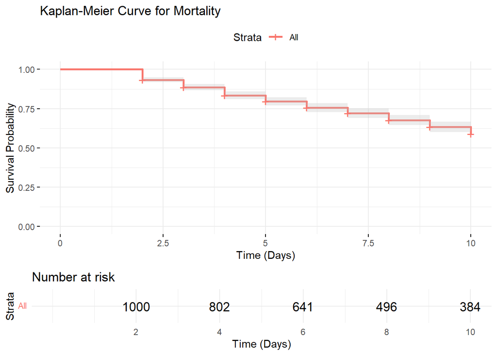

```r
# Filter out rows where both death and discharge are NA
filtered_data <- d_daily %>%
  filter(!(is.na(death) & is.na(discharge)))

# Collapse data to one row per patient
km_data <- filtered_data %>%
  group_by(pt) %>%
  summarise(
    time = max(day, na.rm = TRUE),         # Time to event or censoring
    status = ifelse(any(death == 1), 1, 0) # Event status: 1 if death occurred, 0 otherwise
  ) %>%
  ungroup()

# Fit Kaplan-Meier survival curve
km_fit <- survfit(Surv(time, status) ~ 1, data = km_data)

# Plot Kaplan-Meier curve
ggsurvplot(
  km_fit,
  data = km_data,
  conf.int = TRUE,                # Add confidence intervals
  risk.table = TRUE,              # Show number at risk below the plot
  ggtheme = theme_minimal(),      # Use a minimal theme
  title = "Kaplan-Meier Curve for Mortality",
  xlab = "Time (Days)",
  ylab = "Survival Probability"
)
```

## 3.2 Cox proportional hazards regression using total fluids

```r
# Filter out rows where both death and discharge are NA
filtered_data <- d_daily %>%
  filter(!(is.na(death) & is.na(discharge)))

# Collapse data to one row per patient for survival analysis
cox_data <- filtered_data %>%
  group_by(pt) %>%
  summarise(
    time = max(day, na.rm = TRUE),         # Time to event or censoring
    status = ifelse(any(death == 1), 1, 0), # Event indicator: 1 if death occurred, 0 otherwise
    fluids = sum(fluids, na.rm = TRUE)     # Total fluids as a summary measure (or choose another)
  ) %>%
  ungroup()

# Fit the Cox model with fluids as a covariate
cox_model <- coxph(Surv(time, status) ~ fluids, data = cox_data)

# Summary of the model
summary(cox_model)
```

```
## Call:
## coxph(formula = Surv(time, status) ~ fluids, data = cox_data)
##
##   n= 1000, number of events= 334
##
##            coef exp(coef) se(coef)      z Pr(>|z|)
## fluids -0.40321   0.66817  0.02549 -15.82   <2e-16 ***
## ---
## Signif. codes:  0 '***' 0.001 '**' 0.01 '*' 0.05 '.' 0.1 ' ' 1
##
##        exp(coef) exp(-coef) lower .95 upper .95
## fluids    0.6682      1.497    0.6356    0.7024
##
## Concordance= 0.832  (se = 0.011 )
## Likelihood ratio test= 354.5  on 1 df,   p=<2e-16
## Wald test            = 250.2  on 1 df,   p=<2e-16
## Score (logrank) test = 283.5  on 1 df,   p=<2e-16
```

This of course is again quite biased by LOS. Cumulative fluid balance is now again protective for death as the patients that do not die can keep accumulating fluids.

## 3.3 Cox proportional hazards with time-varying fluid as a covariate

```r
cox_time_varying_data <- d_daily %>%
  filter(!(is.na(death) & is.na(discharge))) %>%  # Remove irrelevant rows
  group_by(pt) %>%
  mutate(
    last_day = max(day, na.rm = TRUE),            # Patient's last observed day
    event_day = ifelse(death == 1, day, NA),      # Day of death if applicable
    status = ifelse(death == 1 & day == last_day, 1, 0)  # Status = 1 for death interval
  ) %>%
  ungroup() %>%
  mutate(
    start = day - 1,  # Start of interval
    stop = day        # Stop of interval
  )

# Fit the Cox model with time-varying covariates
cox_time_varying_model <- coxph(
  Surv(start, stop, status) ~ fluids,
  data = cox_time_varying_data
)

# Summary of the model
summary(cox_time_varying_model)
```

```
## Call:
## coxph(formula = Surv(start, stop, status) ~ fluids, data = cox_time_varying_data)
##
##   n= 5921, number of events= 334
##
##           coef exp(coef) se(coef)     z Pr(>|z|)
## fluids 0.42548   1.53033  0.08316 5.116 3.11e-07 ***
## ---
## Signif. codes:  0 '***' 0.001 '**' 0.01 '*' 0.05 '.' 0.1 ' ' 1
##
##        exp(coef) exp(-coef) lower .95 upper .95
## fluids      1.53     0.6535       1.3     1.801
##
## Concordance= 0.553  (se = 0.017 )
## Likelihood ratio test= 22.94  on 1 df,   p=2e-06
## Wald test            = 26.18  on 1 df,   p=3e-07
## Score (logrank) test = 26.1  on 1 df,   p=3e-07
```

## 3.4 Cox proportional hazards with time-varying fluid and baseline disease severity score as a covariate

```r
# Step 1: Extract the first measured severity for each patient
first_severity <- d_daily %>%
  group_by(pt) %>%
  summarise(severity_first = first(severity[!is.na(severity)])) %>% # First non-NA severity
  ungroup()

# Step 2: Merge the static first severity into the time-varying dataset
cox_static_severity_data <- cox_time_varying_data %>%
  left_join(first_severity, by = "pt")             # Add static severity

# Step 3: Fit the Cox model with static severity
cox_model_static_severity <- coxph(
  Surv(start, stop, status) ~ fluids + severity_first,
  data = cox_static_severity_data
)

# Summary of the model
summary(cox_model_static_severity)
```

```
## Call:
## coxph(formula = Surv(start, stop, status) ~ fluids + severity_first,
##     data = cox_static_severity_data)
##
##   n= 5921, number of events= 334
##
##                   coef exp(coef) se(coef)     z Pr(>|z|)
## fluids         0.27589   1.31770  0.09166 3.010  0.00261 **
## severity_first 0.20157   1.22332  0.04400 4.582 4.62e-06 ***
## ---
## Signif. codes:  0 '***' 0.001 '**' 0.01 '*' 0.05 '.' 0.1 ' ' 1
##
##                exp(coef) exp(-coef) lower .95 upper .95
## fluids             1.318     0.7589     1.101     1.577
## severity_first     1.223     0.8174     1.122     1.333
##
## Concordance= 0.595  (se = 0.017 )
## Likelihood ratio test= 43.92  on 2 df,   p=3e-10
## Wald test            = 46.04  on 2 df,   p=1e-10
## Score (logrank) test = 46.15  on 2 df,   p=1e-10
```

## 3.5 Cox proportional hazards with time-varying fluid and time varying disease severity score as a covariate

```r
cox_model_dynamic_severity <- coxph(
  Surv(start, stop, status) ~ fluids + severity,
  data = cox_time_varying_data
)

# Summary of the adjusted model
summary(cox_model_dynamic_severity)
```

```
## Call:
## coxph(formula = Surv(start, stop, status) ~ fluids + severity,
##     data = cox_time_varying_data)
##
##   n= 5921, number of events= 334
##
##              coef exp(coef) se(coef)      z Pr(>|z|)
## fluids   -0.02284   0.97742  0.10883 -0.210    0.834
## severity  0.22140   1.24783  0.03065  7.224 5.05e-13 ***
## ---
## Signif. codes:  0 '***' 0.001 '**' 0.01 '*' 0.05 '.' 0.1 ' ' 1
##
##          exp(coef) exp(-coef) lower .95 upper .95
## fluids      0.9774     1.0231    0.7897     1.210
## severity    1.2478     0.8014    1.1751     1.325
##
## Concordance= 0.624  (se = 0.017 )
## Likelihood ratio test= 75.81  on 2 df,   p=<2e-16
## Wald test            = 74.6  on 2 df,   p=<2e-16
## Score (logrank) test = 75  on 2 df,   p=<2e-16
```

## 3.6 Summary

```r
# Extract key results from each Cox model
model_results <- data.frame(
  Model = c(
    "Unadjusted (fluids only)",
    "Time-Varying Covariate (fluids)",
    "Baseline Severity Adjusted (fluids)",
    "Baseline Severity Adjusted (severity)",
    "Dynamic Severity Adjusted (fluids)",
    "Dynamic Severity Adjusted (severity)"
  ),
  HR = c(
    exp(coef(cox_model)["fluids"]),
    exp(coef(cox_time_varying_model)["fluids"]),
    exp(coef(cox_model_static_severity)["fluids"]),
    exp(coef(cox_model_static_severity)["severity_first"]),
    exp(coef(cox_model_dynamic_severity)["fluids"]),
    exp(coef(cox_model_dynamic_severity)["severity"])
  ),
  CI_Lower = c(  # Changed to use _
    summary(cox_model)$conf.int["fluids", "lower .95"],
    summary(cox_time_varying_model)$conf.int["fluids", "lower .95"],
    summary(cox_model_static_severity)$conf.int["fluids", "lower .95"],
    summary(cox_model_static_severity)$conf.int["severity_first", "lower .95"],
    summary(cox_model_dynamic_severity)$conf.int["fluids", "lower .95"],
    summary(cox_model_dynamic_severity)$conf.int["severity", "lower .95"]
  ),
  CI_Upper = c(  # Changed to use _
    summary(cox_model)$conf.int["fluids", "upper .95"],
    summary(cox_time_varying_model)$conf.int["fluids", "upper .95"],
    summary(cox_model_static_severity)$conf.int["fluids", "upper .95"],
    summary(cox_model_static_severity)$conf.int["severity_first", "upper .95"],
    summary(cox_model_dynamic_severity)$conf.int["fluids", "upper .95"],
    summary(cox_model_dynamic_severity)$conf.int["severity", "upper .95"]
  ),
  P_value = c(
    summary(cox_model)$coefficients["fluids", "Pr(>|z|)"],
    summary(cox_time_varying_model)$coefficients["fluids", "Pr(>|z|)"],
    summary(cox_model_static_severity)$coefficients["fluids", "Pr(>|z|)"],
    summary(cox_model_static_severity)$coefficients["severity_first", "Pr(>|z|)"],
    summary(cox_model_dynamic_severity)$coefficients["fluids", "Pr(>|z|)"],
    summary(cox_model_dynamic_severity)$coefficients["severity", "Pr(>|z|)"]
  ),
  stringsAsFactors = FALSE
)

# Round values for readability
model_results <- model_results %>%
  mutate(
    HR = round(HR, 2),
    CI_Lower = round(CI_Lower, 2),
    CI_Upper = round(CI_Upper, 2),
    P_value = formatC(P_value, format = "e", digits = 2)
  )

# Create a neat summary table
model_results %>%
  kbl(
    col.names = c("Model", "Hazard Ratio (HR)", "CI Lower", "CI Upper", "P-value"),
    caption = "Summary of Cox Models for Fluids and Severity"
  ) %>%
  kable_styling(
    bootstrap_options = c("striped", "hover", "condensed", "responsive"),
    full_width = FALSE
  )
```

Summary of Cox Models for Fluids and Severity

| Model | Hazard Ratio (HR) | CI Lower | CI Upper | P-value |
| --- | --- | --- | --- | --- |
| Unadjusted (fluids only) | 0.67 | 0.64 | 0.70 | 2.33e-56 |
| Time-Varying Covariate (fluids) | 1.53 | 1.30 | 1.80 | 3.11e-07 |
| Baseline Severity Adjusted (fluids) | 1.32 | 1.10 | 1.58 | 2.61e-03 |
| Baseline Severity Adjusted (severity) | 1.22 | 1.12 | 1.33 | 4.62e-06 |
| Dynamic Severity Adjusted (fluids) | 0.98 | 0.79 | 1.21 | 8.34e-01 |
| Dynamic Severity Adjusted (severity) | 1.25 | 1.18 | 1.33 | 5.05e-13 |

# 4 Taking competing risks into account

One important source of possible bias in our previous analysis is that patients are censored at ICU discharge. One way to adjust for this is to use a Fine-Gray Subdistribution Hazard model. Lets do this

## 4.1 Fine-Gray competing risk analysis for mean fluid balance unadjusted

```r
mean_fluids <- d %>%
  dplyr::select(pt, fluids_mean)

cr_data <- d_daily %>%
  filter(!(is.na(death) & is.na(discharge))) %>%  # Remove rows with no outcomes
  group_by(pt) %>%
  summarise(
    time = max(day, na.rm = TRUE),         # Time to event or censoring
    event = case_when(
      any(death == 1) ~ 1,                 # Event = 1 for death
      any(discharge == 1) ~ 2,             # Event = 2 for discharge
      TRUE ~ 0                             # Event = 0 for censoring
    )
  ) %>%
  ungroup() %>%
    left_join(mean_fluids, by = "pt")  # Add mean fluids to the competing risks dataset





library(cmprsk)

# Fine-Gray model for death (event = 1, competing event = 2) with fluids
fg_unadjusted <- crr(
  ftime = cr_data$time,         # Time-to-event
  fstatus = cr_data$event,      # Event type (1 = death, 2 = discharge, 0 = censored)
  cov1 = as.matrix(cr_data$fluids_mean)  # Fluids as a covariate
)

# Summary of the Fine-Gray model
summary(fg_unadjusted)
```

```
## Competing Risks Regression
##
## Call:
## crr(ftime = cr_data$time, fstatus = cr_data$event, cov1 = as.matrix(cr_data$fluids_mean))
##
##                                  coef exp(coef) se(coef)    z p-value
## as.matrix(cr_data$fluids_mean)1 0.871      2.39    0.131 6.64 3.2e-11
##
##                                 exp(coef) exp(-coef) 2.5% 97.5%
## as.matrix(cr_data$fluids_mean)1      2.39      0.418 1.85  3.09
##
## Num. cases = 1000
## Pseudo Log-likelihood = -2235
## Pseudo likelihood ratio test = 33.6  on 1 df,
```

## 4.2 Fine-Gray competing risk analysis with adjustment for baseline disease severity

```r
mean_fluids_severity_baseline <- d %>%
  select(pt, fluids_mean, severity_baseline)

cr_data <- d_daily %>%
  filter(!(is.na(death) & is.na(discharge))) %>%  # Remove rows with no outcomes
  group_by(pt) %>%
  summarise(
    time = max(day, na.rm = TRUE),         # Time to event or censoring
    event = case_when(
      any(death == 1) ~ 1,                 # Event = 1 for death
      any(discharge == 1) ~ 2,             # Event = 2 for discharge
      TRUE ~ 0                             # Event = 0 for censoring
    )
  ) %>%
  ungroup() %>%
    left_join(mean_fluids_severity_baseline, by = "pt")  # Add mean fluids to the competing risks dataset





library(cmprsk)

# Fine-Gray model for death (event = 1, competing event = 2) with fluids
fg_adjusted <- crr(
  ftime = cr_data$time,         # Time-to-event
  fstatus = cr_data$event,      # Event type (1 = death, 2 = discharge, 0 = censored)
  cov1 = as.matrix(cr_data[, c("fluids_mean", "severity_baseline")])  # Fluids as a covariate
)

# Summary of the Fine-Gray model
summary(fg_adjusted)
```

```
## Competing Risks Regression
##
## Call:
## crr(ftime = cr_data$time, fstatus = cr_data$event, cov1 = as.matrix(cr_data[,
##     c("fluids_mean", "severity_baseline")]))
##
##                    coef exp(coef) se(coef)    z p-value
## fluids_mean       0.713      2.04   0.1499 4.76 2.0e-06
## severity_baseline 0.155      1.17   0.0607 2.55 1.1e-02
##
##                   exp(coef) exp(-coef) 2.5% 97.5%
## fluids_mean            2.04      0.490 1.52  2.74
## severity_baseline      1.17      0.857 1.04  1.31
##
## Num. cases = 1000
## Pseudo Log-likelihood = -2232
## Pseudo likelihood ratio test = 40  on 2 df,
```

So once again we see that if we look at mean fluid balance with or without adjustment for baseline disease severity, there will be an apparent association. Previously, we could take into account varying disease severity. We could do this with landmark analysis, but we lose granularity. We could also try subdistribution hazards with Cox models and time varying disease severity (like previously). However, in that case we would assume death and ICU discharge are indepedent events which is clearly not the case.

# 5 Marginal structural modeling

One solution could be marginal structural modeling. Lets try.

## 5.1 Approach using twangContinous and weighted cox PH.

I ran into some issues here. It is important to note that fluid is a numerical continous variable. Previous papers such as https://pubmed.ncbi.nlm.nih.gov/25422275/ did a counterfactual analysis by modelling the exposure variable with the IPW package. But this variable was a binary exposure variable. I could not get it to work with the IPW package and a continuous exposure variable

I also tried using twang but this does not work as it can also not deal with continuous exposure variables. Then I found twangContinous (https://pubmed.ncbi.nlm.nih.gov/26877909/). Importantly, this tool does not handle differences in the days with available data well. For that reason I used carry-forward imputation (is this appropriate?)

```r
# Load required libraries
library(dplyr)
library(tidyr)
# Prepare the dataset with carry-forward imputation (Appropriate?)
d_daily_imputed <- d_daily %>%
  group_by(pt) %>%
  arrange(pt, day) %>%
  mutate(
    fluids = zoo::na.locf(fluids, na.rm = FALSE),   # Carry-forward imputation
    severity = zoo::na.locf(severity, na.rm = FALSE)
  ) %>%
  ungroup() %>%
  filter(day > 1)
d_daily_imputed <- as.data.frame(d_daily_imputed)


# Define the IPTW formula for longitudinal treatment MSM
ps_formula <- fluids ~ severity

# Fit the model using twangContinuous
library(twangContinuous)

ps_fit <- ps.cont(
  formula = ps_formula,
  data = d_daily_imputed,
  n.trees = 10000,           # Number of boosting iterations
  interaction.depth = 3,   # Depth of trees
  shrinkage = 0.01,        # Learning rate
  stop.method = "wcor",    # Weighted correlation stopping method
  verbose = TRUE           # Monitor progress
)
```

```
## Fitting gbm model
##
## Diagnosis of unweighted analysis
## Estimating marginal density of the treatment Optimizing stopping rule
## Optimized at 1801
## Diagnosis of weights
```

```r
# Summary of the propensity score model
summary(ps_fit)
```

```
##        n        ess  max.wcor mean.wcor  rms.wcor iter
## unw 9000 9000.00000 0.5715478 0.5715478 0.5715478   NA
## AAC 9000   61.59998 0.1002838 0.1002838 0.1002838 1801
```

```r
# Extract balance table for diagnostics
bal <- bal.table(ps_fit)
print(bal)
```

```
##            unw wcor
## severity 0.572  0.1
```

```r
# Add weights to the dataset
d_daily_imputed <- d_daily_imputed %>%
  mutate(weights = ps_fit$w)

# Summary of weights
summary(d_daily_imputed$weights)
```

```
##      Min.   1st Qu.    Median      Mean   3rd Qu.      Max.
##    0.0000    0.6616    0.7615    1.5189    0.9463 1261.5904
```

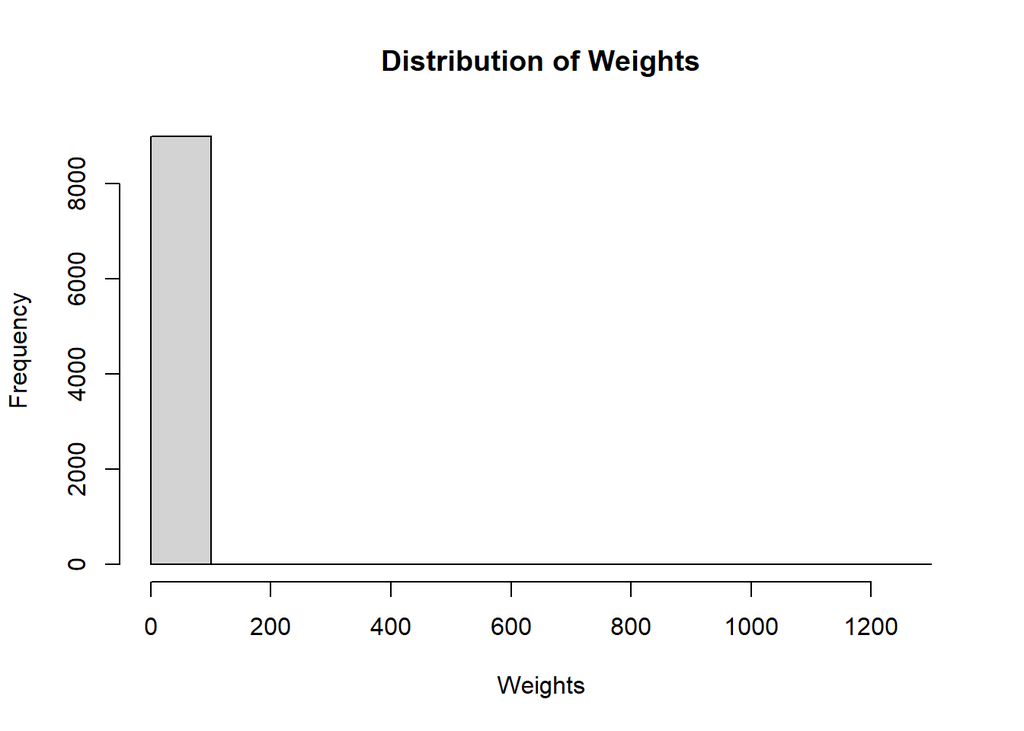

```r
# Visualize weights
hist(d_daily_imputed$weights, main = "Distribution of Weights", xlab = "Weights")
```

```r
# Define truncation limits
truncation_limits <- c(0.01, 0.99)

# Truncate weights
d_daily_imputed <- d_daily_imputed %>%
  mutate(
    truncated_weights = pmin(
      pmax(weights, quantile(weights, truncation_limits[1])),
      quantile(weights, truncation_limits[2])
    )
  )

# Check truncated weights
summary(d_daily_imputed$truncated_weights)
```

```
##    Min. 1st Qu.  Median    Mean 3rd Qu.    Max.
## 0.04533 0.66163 0.76151 0.92255 0.94633 5.53993
```

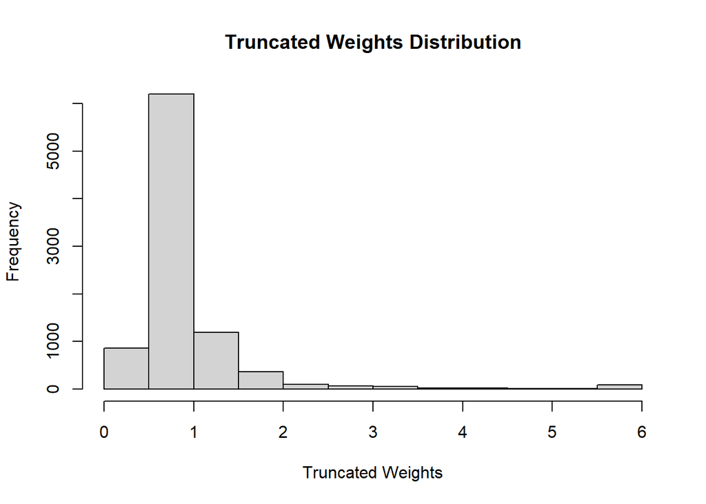

```r
hist(d_daily_imputed$truncated_weights, main = "Truncated Weights Distribution", xlab = "Truncated Weights")
```

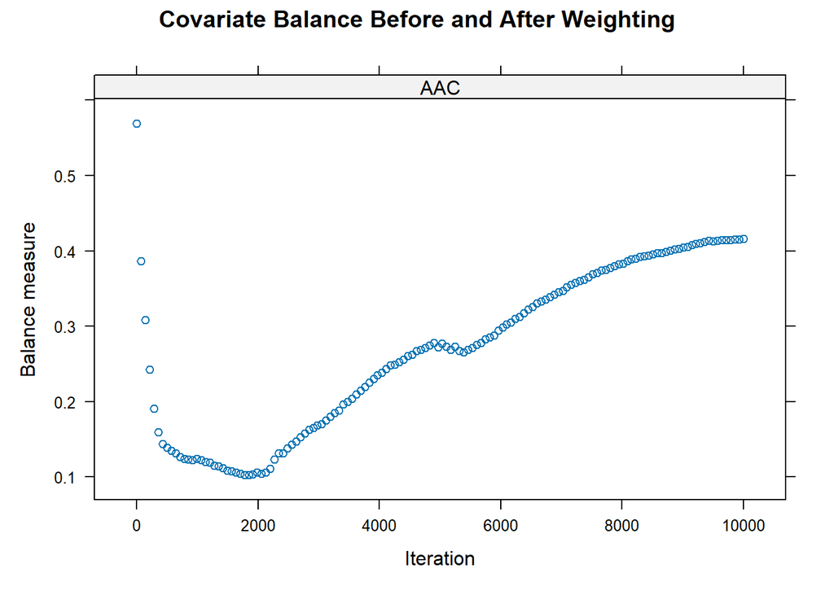

```r
plot(ps_fit, main = "Covariate Balance Before and After Weighting")
```

```r
# Define start/stop times for survival analysis
msm_data <- d_daily_imputed %>%
  mutate(
    start = ifelse(day == min(day), 0, day - 1),
    stop = day
  )

# Fit weighted Cox PH model
msm_model <- coxph(
  Surv(start, stop, death == 1) ~ fluids,
  data = msm_data,
  weights = msm_data$truncated_weights
)

# Display results
summary(msm_model)
```

```
## Call:
## coxph(formula = Surv(start, stop, death == 1) ~ fluids, data = msm_data,
##     weights = msm_data$truncated_weights)
##
##   n= 5921, number of events= 334
##    (3079 observations deleted due to missingness)
##
##            coef exp(coef) se(coef) robust se      z Pr(>|z|)
## fluids -0.09508   0.90930  0.09906   0.17091 -0.556    0.578
##
##        exp(coef) exp(-coef) lower .95 upper .95
## fluids    0.9093        1.1    0.6505     1.271
##
## Concordance= 0.521  (se = 0.019 )
## Likelihood ratio test= 0.95  on 1 df,   p=0.3
## Wald test            = 0.31  on 1 df,   p=0.6
## Score (logrank) test = 0.92  on 1 df,   p=0.3,   Robust = 0.34  p=0.6
##
##   (Note: the likelihood ratio and score tests assume independence of
##      observations within a cluster, the Wald and robust score tests do not).
```

I then came across this article: https://www.degruyter.com/document/doi/10.1515/jci-2017-0002/html about Covariate Balancing Inverse Probability Weights for Time-Varying Continuous Interventions. Unfortunately, they do not have the code publically available so instead we calculate non-parametric CBPS fort he IPTW and then do a cox-ph.

```r
# Load necessary libraries
library(CBPS)
# Prepare the dataset with carry-forward imputation
d_daily_imputed_cbps <- d_daily %>%
  group_by(pt) %>%
  arrange(pt, day) %>%
  mutate(
    fluids = zoo::na.locf(fluids, na.rm = FALSE),   # Carry-forward imputation
    severity = zoo::na.locf(severity, na.rm = FALSE)
  ) %>%
  ungroup() %>%
  filter(day > 1)

d_daily_imputed_cbps <- as.data.frame(d_daily_imputed_cbps)



# Fit the npCBPS model
npCBPS_fit <- npCBPS(
  formula = fluids ~ severity,  # Treatment ~ Covariates
  data = d_daily_imputed_cbps,
  corprior = 0.01,             # Default prior for correlation
  print.level = 1              # Verbosity for diagnostics
)
```

[output not shown]

```r
# Summary of the npCBPS model
summary(npCBPS_fit)
```

```
##           Length Class      Mode
## par          1   -none-     numeric
## log.p.eta    1   -none-     numeric
## log.el       1   -none-     numeric
## eta          1   -none-     numeric
## sumw0        1   -none-     numeric
## weights   9000   -none-     numeric
## y         9000   -none-     numeric
## x         9000   -none-     numeric
## data         6   data.frame list
## call         5   -none-     call
## formula      3   formula    call
## terms        3   terms      call
```

```r
# Extract weights
d_daily_imputed_cbps$weights <- npCBPS_fit$weights


# Summary of weights
summary(d_daily_imputed$weights)
```

```
##      Min.   1st Qu.    Median      Mean   3rd Qu.      Max.
##    0.0000    0.6616    0.7615    1.5189    0.9463 1261.5904
```

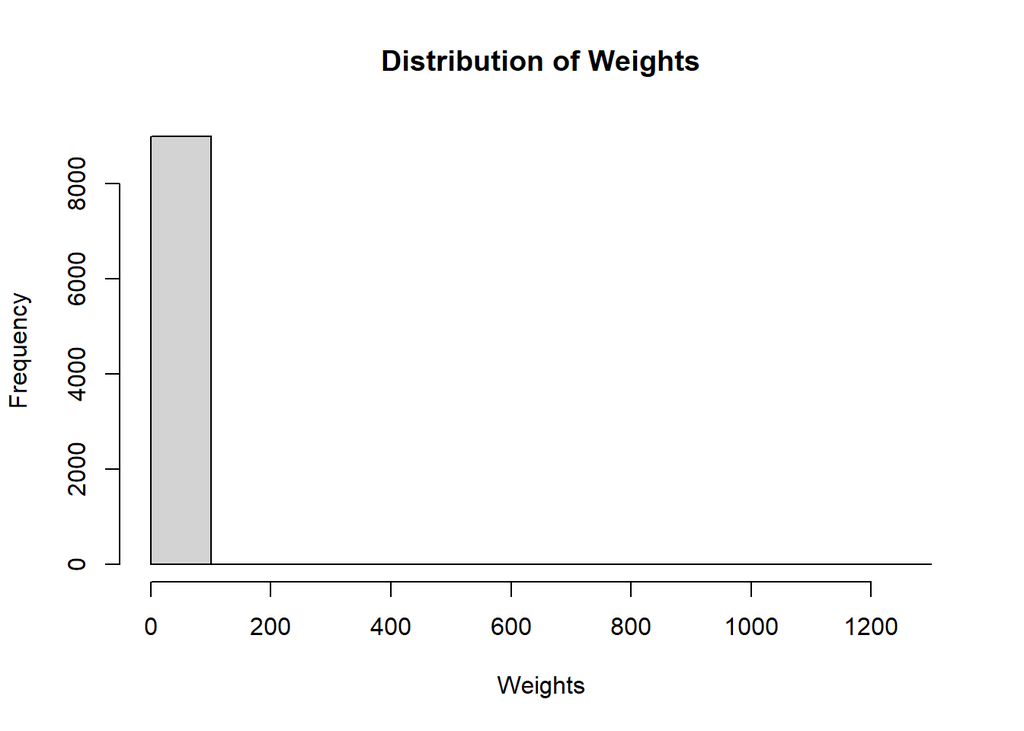

```r
# Visualize weight distribution
hist(d_daily_imputed$weights, main = "Distribution of Weights", xlab = "Weights")
```

```r
# Define truncation limits
truncation_limits <- c(0.01, 0.99)

# Truncate weights
d_daily_imputed_cbps <- d_daily_imputed_cbps %>%
  mutate(
    truncated_weights = pmin(
      pmax(weights, quantile(weights, truncation_limits[1])),
      quantile(weights, truncation_limits[2])
    )
  )

# Check summary of truncated weights
summary(d_daily_imputed_cbps$truncated_weights)
```

```
##      Min.   1st Qu.    Median      Mean   3rd Qu.      Max.
## 4.868e-05 1.011e-04 1.144e-04 1.096e-04 1.201e-04 1.494e-04
```

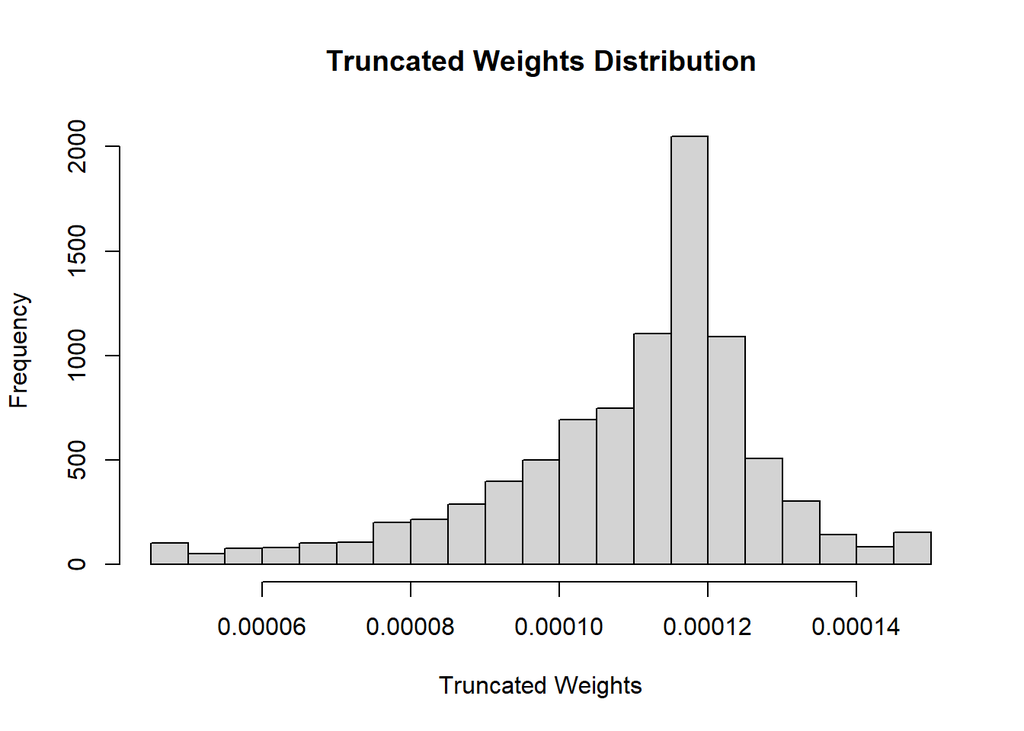

```r
# Visualize the distribution of truncated weights
hist(d_daily_imputed_cbps$truncated_weights, main = "Truncated Weights Distribution", xlab = "Truncated Weights")
```

```r
d_daily_imputed_cbps <- d_daily_imputed_cbps %>%
  mutate(
    start = ifelse(day == min(day), 0, day - 1),
    stop = day
  )

# Fit the Marginal Structural Model (MSM)
msm_model_nCBPS <- coxph(
  Surv(start, stop, death == 1) ~ fluids,   # Marginal effect of fluids
  data = d_daily_imputed_cbps,                         # Long-format data
  weights = d_daily_imputed_cbps$truncated_weights           # CBPS-derived weights as IPWs
)

# Display the MSM summary
summary(msm_model_nCBPS)
```

```
## Call:
## coxph(formula = Surv(start, stop, death == 1) ~ fluids, data = d_daily_imputed_cbps,
##     weights = d_daily_imputed_cbps$truncated_weights)
##
##   n= 5921, number of events= 334
##    (3079 observations deleted due to missingness)
##
##           coef exp(coef) se(coef) robust se     z Pr(>|z|)
## fluids 0.31807   1.37448  9.80026   0.09018 3.527  0.00042 ***
## ---
## Signif. codes:  0 '***' 0.001 '**' 0.01 '*' 0.05 '.' 0.1 ' ' 1
##
##        exp(coef) exp(-coef) lower .95 upper .95
## fluids     1.374     0.7275     1.152      1.64
##
## Concordance= 0.531  (se = 0.017 )
## Likelihood ratio test= 0  on 1 df,   p=1
## Wald test            = 12.44  on 1 df,   p=4e-04
## Score (logrank) test = 0  on 1 df,   p=1,   Robust = 9.95  p=0.002
##
##   (Note: the likelihood ratio and score tests assume independence of
##      observations within a cluster, the Wald and robust score tests do not).
```

With this method the bias persists. Maybe I am doing something wrong?

## 5.2 Plot observed and counterfactual survival (am I doing this correctly>)

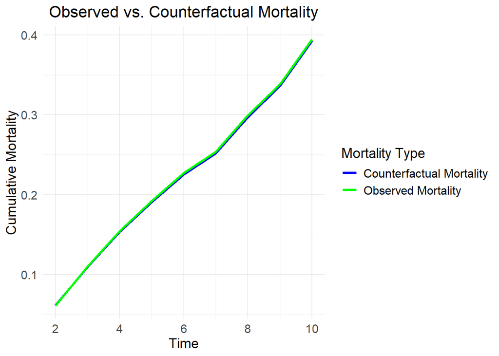

```r
#Predict survival probabilities under observed and counterfactual exposures

# Observed survival probabilities
msm_surv_observed <- survfit(msm_model)

# Counterfactual: Set fluids to a specific level (e.g., median)
counterfactual_data <- msm_data %>%
  mutate(fluids = median(fluids))  # Replace with counterfactual level

# Predict survival probabilities under counterfactual scenario
msm_model_counterfactual <- coxph(
  Surv(start, stop, death == 1) ~ fluids,
  data = counterfactual_data,
  weights = truncated_weights  # Use the same weights
)
msm_surv_counterfactual <- survfit(msm_model_counterfactual)

#Compute attributable mortality
# Mortality = 1 - Survival Probability
time_points <- msm_surv_observed$time
mortality_observed <- 1 - msm_surv_observed$surv
mortality_counterfactual <- 1 - msm_surv_counterfactual$surv

# Attributable Mortality
attributable_mortality <- mortality_observed - mortality_counterfactual

# Load ggplot2
library(ggplot2)
library(dplyr)

# Step 1: Prepare the data for ggplot
plot_data <- data.frame(
  time = msm_surv_observed$time,
  mortality_observed = 1 - msm_surv_observed$surv,
  mortality_counterfactual = 1 - msm_surv_counterfactual$surv
) %>%
  pivot_longer(
    cols = c(mortality_observed, mortality_counterfactual),
    names_to = "Type",
    values_to = "Mortality"
  ) %>%
  mutate(Type = recode(Type,
                       "mortality_observed" = "Observed Mortality",
                       "mortality_counterfactual" = "Counterfactual Mortality"))

# Step 2: Create the plot
ggplot(plot_data, aes(x = time, y = Mortality, color = Type)) +
  geom_line(size = 1.2) +
  labs(
    title = "Observed vs. Counterfactual Mortality",
    x = "Time",
    y = "Cumulative Mortality",
    color = "Mortality Type"
  ) +
  scale_color_manual(values = c("blue", "green")) +
  theme_minimal() +
  theme(
    plot.title = element_text(hjust = 0.5, size = 16),
    axis.title = element_text(size = 14),
    axis.text = element_text(size = 12),
    legend.title = element_text(size = 14),
    legend.text = element_text(size = 12)
  )
```

As you can see here there is no difference between observed or counterfactual mortality (if all patients received the median fluid balance on all days)

# 6 Competing risk analysis after IPTW (marginal structural competing risk model)

This I have not figured out yet. I can not find a function that can do a competing risk analysis that can use the IPTW that are different for each observed day.

# 7 Conclusion

There are multiple ways to approach this problem. It seems that in this simulated dataset we actually got a better estimate of the actual effect by using a time varying cox model than by using a marginal structural model. Implementing competing risks could be an important next step, however to answer our research question it might actually not be needed?